# NSW Road Crash Severity Prediction

#### 6.2 Decision Tree - CP pruning

```r
# Decision Tree improvement  -  tune complexity by pruning via CP table
# 1. First grow a deeper tree (relax the cp parameter to 0.001) to find the optimal split points
model_dt_deep <- rpart(
  Degree.of.crash ~ .,
  data = train_dt,
  method = "class",
  weights = dt_weights,
  control = rpart.control(cp = 0.001, xval = 5) # xval=5
)

# 2. Extract the CP with minimum xerror from the deep tree
best_cp <- model_dt_deep$cptable[which.min(model_dt_deep$cptable[, "xerror"]), "CP"]
cat("Best cp from xerror minimisation:", best_cp, "\n")

# 3. ggplot CP tuning curve (used in tuning-curves grid - avoids draw_image/magick dependency)
best_nsplit <- model_dt_deep$cptable[which.min(model_dt_deep$cptable[, "xerror"]), "nsplit"]
p_dt_tune <- as.data.frame(model_dt_deep$cptable) %>%
  ggplot(aes(x = nsplit, y = xerror)) +
  geom_line(colour = "#2E74B5", linewidth = 1) +
  geom_point(size = 2.5, colour = "#2E74B5") +
  geom_errorbar(aes(ymin = xerror - xstd, ymax = xerror + xstd), width = 0.3, alpha = 0.4) +
  geom_vline(xintercept = best_nsplit, linetype = "dashed", colour = "#C0392B") +
  annotate("text", x = best_nsplit, y = max(model_dt_deep$cptable[, "xerror"]),
           label = paste("Best cp =", signif(best_cp, 3)),
           hjust = -0.1, colour = "#C0392B", size = 3.5) +
  labs(title = "DT Tuning: Splits vs CV Error",
       x = "Number of Splits", y = "CV Error (xerror)") +
  theme_minimal(base_size = 12)
ggsave("plots/6_2_decision_tree_cp_plot.png", p_dt_tune, width = 7, height = 5, dpi = 150)

# 4. Prune the deep tree using the optimal CP found
model_dt_tuned <- prune(model_dt_deep, cp = best_cp)

# 5. Evaluate the pruned model on the test set
pred_dt_tuned <- predict(model_dt_tuned, newdata = test_dt, type = "class")
cm_dt_tuned <- confusionMatrix(pred_dt_tuned, test_dt$Degree.of.crash)

fatal_recall_dt_tuned <- as.numeric(cm_dt_tuned$byClass["Class: Fatal", "Recall"])
f1_dt_tuned_vec <- setNames(cm_dt_tuned$byClass[, "F1"], gsub("Class: ", "", rownames(cm_dt_tuned$byClass)))
macro_f1_dt_tuned <- mean(f1_dt_tuned_vec, na.rm = TRUE)
weighted_f1_dt_tuned <- weighted.mean(f1_dt_tuned_vec[names(test_props_dt)], test_props_dt, na.rm = TRUE)
kappa_dt_tuned <- as.numeric(cm_dt_tuned$overall["Kappa"])

cat(sprintf(
  "   Decision Tree (Tuned)  -  Test Set Metrics\nMacro-F1     : %.4f\nFatal Recall : %.4f\nWeighted F1  : %.4f\nKappa        : %.4f\n",
  macro_f1_dt_tuned, fatal_recall_dt_tuned, weighted_f1_dt_tuned, kappa_dt_tuned
))

# 6. Generate Before/After comparison table
before_after_dt <- data.frame(
  Model = c("DT: default cp (0.01)", paste0("DT: tuned cp (", signif(best_cp, 3), ")")),
  `Macro-F1` = round(c(macro_f1_dt, macro_f1_dt_tuned), 4),
  `Fatal Recall` = round(c(fatal_recall_dt, fatal_recall_dt_tuned), 4),
  check.names = FALSE
)
knitr::kable(before_after_dt, caption = "Decision Tree  -  Before vs After Pruning")

# 7. Plot Tuned Confusion Matrix heatmap
p_dt_tuned_cm <- as.data.frame(cm_dt_tuned$table) %>%
  ggplot(aes(x = Reference, y = Prediction, fill = Freq)) +
  geom_tile(colour = "white") +
  geom_text(aes(label = Freq), size = 6, fontface = "bold") +
  scale_fill_gradient(low = "white", high = "#1F4E79") +
  labs(
    title = "Decision Tree (Tuned) - Confusion Matrix",
    subtitle = paste0("Fatal Recall: ", round(fatal_recall_dt_tuned, 3),
                      "  |  Macro-F1: ", round(macro_f1_dt_tuned, 3)),
    x = "Actual", y = "Predicted"
  ) +
  theme_minimal(base_size = 12) +
  theme(legend.position = "none",
        plot.title = element_text(size = 10))
print(p_dt_tuned_cm)
```

[output not shown]

```r
ggsave("plots/6_2_decision_tree_tuned_confusion_matrix.png", p_dt_tuned_cm, width = 7, height = 5, dpi = 150)
```

#### 6.3 Random Forest - mtry tuning

```r
invisible(capture.output(
  tune_result <- tuneRF(
    x          = rf_x_train,
    y          = df_train_bal$`Degree of crash`,
    mtryStart  = floor(sqrt(ncol(rf_x_train))),
    ntreeTry   = 50,
    stepFactor = 1.5,
    improve    = 0.01,
    trace      = FALSE,
    plot       = FALSE
  )
))
best_mtry <- tune_result[which.min(tune_result[, "OOBError"]), "mtry"]
cat("Best mtry from tuneRF:", best_mtry, "\n")

# mtry vs OOB error curve
p_rf_tune <- as.data.frame(tune_result) %>%
  ggplot(aes(x = mtry, y = OOBError)) +
  geom_line(colour = "#2E74B5", linewidth = 1) +
  geom_point(size = 3, colour = "#2E74B5") +
  geom_vline(xintercept = best_mtry, linetype = "dashed", colour = "#C0392B") +
  annotate("text", x = best_mtry, y = max(tune_result[, "OOBError"]),
           label = paste("Best mtry =", best_mtry),
           hjust = 1.1, colour = "#C0392B", size = 3.5) +
  labs(title = "RF Tuning: mtry vs OOB Error",
       x = "mtry (variables randomly sampled per split)", y = "OOB Error Rate") +
  theme_minimal(base_size = 12)
print(p_rf_tune)
```

[output not shown]

```r
ggsave("plots/6_3_random_forest_mtry_tuning_curve.png", p_rf_tune, width = 7, height = 5, dpi = 150)

# Final tuned RF - df_train_bal (balanced) with best_mtry from tuneRF
model_rf_tuned <- randomForest(
  x          = rf_x_train,
  y          = df_train_bal$`Degree of crash`,
  mtry       = best_mtry,
  ntree      = 100,
  importance = TRUE
)

pred_rf_tuned      <- predict(model_rf_tuned, rf_x_test)
cm_rf_tuned        <- confusionMatrix(pred_rf_tuned, df_test$`Degree of crash`)
fatal_recall_tuned <- cm_rf_tuned$byClass["Class: Fatal", "Recall"]
macro_f1_tuned     <- mean(cm_rf_tuned$byClass[, "F1"], na.rm = TRUE)
weighted_f1_tuned  <- weighted.mean(cm_rf_tuned$byClass[, "F1"],
                       prop.table(table(df_test$`Degree of crash`)), na.rm = TRUE)
kappa_tuned        <- cm_rf_tuned$overall["Kappa"]

cat(sprintf(
  "    RF Tuned   -   Test Set Metrics \nOOB error rate : %.4f\nMacro-F1       : %.4f\nFatal Recall   : %.4f\nWeighted F1    : %.4f\nKappa          : %.4f\n",
  model_rf_tuned$err.rate[100, "OOB"], macro_f1_tuned, fatal_recall_tuned, weighted_f1_tuned, kappa_tuned
))

# Before / After comparison table
data.frame(
  Model          = c("RF : default mtry", "RF : tuned mtry"),
  mtry           = c(floor(sqrt(ncol(rf_x_train))), best_mtry),
  `Macro-F1`     = round(c(macro_f1_rf,    macro_f1_tuned),    4),
  `Fatal Recall` = round(c(fatal_recall_rf, fatal_recall_tuned), 4),
  check.names = FALSE
) %>% knitr::kable(caption = "Random Forest  -  Before vs After Tuning")

# Plot 2: OOB error vs ntree convergence curve
p_rf_oob <- data.frame(ntree = seq_len(nrow(model_rf_tuned$err.rate)),
           OOB   = model_rf_tuned$err.rate[, "OOB"]) %>%
  ggplot(aes(x = ntree, y = OOB)) +
  geom_line(colour = "#2E74B5") +
  labs(title = "Random Forest : OOB Error vs Number of Trees (tuned mtry)",
       x = "Number of trees", y = "OOB error rate") +
  theme_minimal(base_size = 12)
print(p_rf_oob)
```

[output not shown]

```r
ggsave("plots/6_3_random_forest_oob_convergence.png", p_rf_oob, width = 7, height = 5, dpi = 150)

# Plot 3: Confusion matrix heatmap  -  tuned model (last in row)
p_rf_tuned_cm <- as.data.frame(cm_rf_tuned$table) %>%
  ggplot(aes(x = Reference, y = Prediction, fill = Freq)) +
  geom_tile(colour = "white") +
  geom_text(aes(label = Freq), size = 6, fontface = "bold") +
  scale_fill_gradient(low = "white", high = "#1F4E79") +
  labs(title = "Random Forest (Tuned) - Confusion Matrix",
       subtitle = paste0("Fatal Recall: ", round(fatal_recall_tuned, 3),
                         "  |  Macro-F1: ", round(macro_f1_tuned, 3)),
       x = "Actual", y = "Predicted") +
  theme_minimal(base_size = 12) +
  theme(legend.position = "none",
        plot.title = element_text(size = 10))
print(p_rf_tuned_cm)
```

[output not shown]

```r
ggsave("plots/6_3_random_forest_tuned_confusion_matrix.png", p_rf_tuned_cm, width = 7, height = 5, dpi = 150)
```

#### 6.4 XGBoost - grid search with early stopping

```r
valid_idx <- createDataPartition(
  y_train_factor,
  p = 0.2,
  list = FALSE
)

x_valid_mm <- x_train_mm[valid_idx, , drop = FALSE]

y_valid_factor <- y_train_factor[valid_idx]

y_valid <- y_train[valid_idx]

x_subtrain_mm <- x_train_mm[-valid_idx, , drop = FALSE]

y_subtrain_factor <- y_train_factor[-valid_idx]

y_subtrain <- y_train[-valid_idx]

class_counts_sub <- table(y_subtrain_factor)

class_weights_sub <- sum(class_counts_sub) / (length(class_counts_sub) * class_counts_sub)

obs_weights_sub <- as.numeric(class_weights_sub[y_subtrain_factor])

dsubtrain <- xgb.DMatrix(
  data = x_subtrain_mm,
  label = y_subtrain,
  weight = obs_weights_sub
)

dvalid <- xgb.DMatrix(
  data = x_valid_mm,
  label = y_valid
)

# Small grid: 2 depths x 3 etas = 6 combinations
# nrounds is determined automatically via early stopping (patience = 20 rounds)
xgb_tune_grid <- expand.grid(
  max_depth = c(3, 5),
  eta       = c(0.05, 0.1, 0.3)
)

evaluate_xgb_grid <- function(max_depth, eta) {
  params <- list(
    objective        = "multi:softprob",
    num_class        = length(class_levels),
    eval_metric      = "mlogloss",
    max_depth        = max_depth,
    eta              = eta,
    gamma            = 0,
    colsample_bytree = 1,
    min_child_weight = 1,
    subsample        = 1
  )

  model <- xgb.train(
    params              = params,
    data                = dsubtrain,
    nrounds             = 500,
    watchlist           = list(val = dvalid),
    early_stopping_rounds = 20,
    verbose             = 0
  )

  bi <- model$best_iteration
  best_nrounds <- if (is.null(bi) || length(bi) == 0 || is.na(bi) || bi < 1L) 500L else as.integer(bi)

  pred_prob        <- predict(model, dvalid)
  pred_prob_matrix <- matrix(pred_prob, ncol = length(class_levels), byrow = TRUE)
  pred_index       <- max.col(pred_prob_matrix) - 1
  pred_class       <- factor(class_levels[pred_index + 1], levels = class_levels)

  cm       <- confusionMatrix(data = pred_class, reference = y_valid_factor)
  by_class <- as.data.frame(cm$byClass)
  by_class$Class <- rownames(by_class)
  rownames(by_class) <- NULL

  tibble(
    max_depth    = max_depth,
    eta          = eta,
    best_nrounds = best_nrounds,
    Accuracy     = as.numeric(cm$overall["Accuracy"]),
    Kappa        = as.numeric(cm$overall["Kappa"]),
    Mean_F1      = mean(by_class$F1, na.rm = TRUE),
    Fatal_Recall = by_class %>% filter(Class == "Class: Fatal") %>% pull(Sensitivity)
  )
}

xgb_tune_results <- bind_rows(
  lapply(seq_len(nrow(xgb_tune_grid)), function(i) {
    evaluate_xgb_grid(
      max_depth = xgb_tune_grid$max_depth[i],
      eta       = xgb_tune_grid$eta[i]
    )
  })
)

best_xgb_params <- xgb_tune_results %>%
  arrange(desc(Mean_F1), desc(Fatal_Recall)) %>%
  slice(1)

# Tuning plot: Mean-F1 for each setting (colour = eta, x = max_depth)
p_xgb_tune_curve <- xgb_tune_results %>%
  mutate(setting = paste0("depth=", max_depth, ", eta=", eta),
         eta_lbl = factor(paste0("eta=", eta))) %>%
  ggplot(aes(x = factor(max_depth), y = Mean_F1, fill = eta_lbl)) +
  geom_col(position = "dodge") +
  geom_text(aes(label = round(Mean_F1, 3)), position = position_dodge(0.9),
            vjust = 1.4, size = 2.6, colour = "white", fontface = "bold") +
  scale_fill_brewer(palette = "Blues", direction = 1) +
  labs(title = "XGBoost Tuning: Mean-F1 by Depth & Learning Rate",
       x = "max_depth", y = "Validation Mean-F1", fill = "Learning rate") +
  theme_minimal(base_size = 12) +
  theme(plot.title = element_text(size = 10))

dir.create("plots", showWarnings = FALSE)

ggsave(
  "plots/6_4_xgboost_tuning_curve.png",
  p_xgb_tune_curve,
  width = 7,
  height = 5,
  dpi = 150
)

class_counts_full <- table(y_train_factor)

class_weights_full <- sum(class_counts_full) /
  (length(class_counts_full) * class_counts_full)

obs_weights_full <- as.numeric(class_weights_full[y_train_factor])

dtrain_full <- xgb.DMatrix(
  data = x_train_mm,
  label = y_train,
  weight = obs_weights_full
)

dtest_full <- xgb.DMatrix(
  data = x_test_mm,
  label = y_test
)

xgb_tuned_params <- list(
  objective = "multi:softprob",
  num_class = length(class_levels),
  eval_metric = "mlogloss",
  max_depth = best_xgb_params$max_depth,
  eta = best_xgb_params$eta,
  gamma = 0,
  colsample_bytree = 1,
  min_child_weight = 1,
  subsample = 1
)

xgb_fit_tuned <- xgb.train(
  params = xgb_tuned_params,
  data = dtrain_full,
  nrounds = max(1L, as.integer(best_xgb_params$best_nrounds)),
  verbose = 0
)

xgb_tuned_prob <- predict(xgb_fit_tuned, dtest_full)

xgb_tuned_prob_matrix <- matrix(
  xgb_tuned_prob,
  ncol = length(class_levels),
  byrow = TRUE
)

xgb_tuned_pred_index <- max.col(xgb_tuned_prob_matrix) - 1

xgb_tuned_pred <- factor(
  class_levels[xgb_tuned_pred_index + 1],
  levels = class_levels
)

cm_xgb_tuned <- confusionMatrix(
  data = xgb_tuned_pred,
  reference = y_test_factor
)

by_class_xgb_tuned <- as.data.frame(cm_xgb_tuned$byClass)

by_class_xgb_tuned$Class <- rownames(by_class_xgb_tuned)

rownames(by_class_xgb_tuned) <- NULL

accuracy_xgb_tuned <- as.numeric(cm_xgb_tuned$overall["Accuracy"])

kappa_xgb_tuned <- as.numeric(cm_xgb_tuned$overall["Kappa"])

macro_f1_xgb_tuned <- mean(
  by_class_xgb_tuned$F1,
  na.rm = TRUE
)

fatal_recall_xgb_tuned <- by_class_xgb_tuned %>%
  filter(Class == "Class: Fatal") %>%
  pull(Sensitivity)

weighted_f1_xgb_tuned <- weighted.mean(
  by_class_xgb_tuned$F1,
  prop.table(table(y_test_factor))[gsub("Class: ", "", by_class_xgb_tuned$Class)],
  na.rm = TRUE
)

xgb_before_after <- tibble(
  Model = c("XGBoost baseline", "XGBoost tuned"),
  Accuracy = c(accuracy_xgb, accuracy_xgb_tuned),
  Macro_F1 = c(macro_f1_xgb, macro_f1_xgb_tuned),
  Fatal_Recall = c(fatal_recall_xgb, fatal_recall_xgb_tuned),
  Weighted_F1 = c(weighted_f1_xgb, weighted_f1_xgb_tuned),
  Kappa = c(kappa_xgb, kappa_xgb_tuned)
)

xgb_before_after %>%
  mutate(across(where(is.numeric), ~ round(., 3)))

p_xgb_tuned_cm <- as.data.frame(cm_xgb_tuned$table) %>%
  ggplot(aes(x = Reference, y = Prediction, fill = Freq)) +
  geom_tile(colour = "white") +
  geom_text(aes(label = Freq), size = 6, fontface = "bold") +
  scale_fill_gradient(low = "white", high = "#1F4E79") +
  labs(
    title = "XGBoost (Tuned) - Confusion Matrix",
    subtitle = paste0("Fatal Recall: ", round(fatal_recall_xgb_tuned, 3),
                      "  |  Macro-F1: ", round(macro_f1_xgb_tuned, 3)),
    x = "Actual", y = "Predicted"
  ) +
  theme_minimal(base_size = 12) +
  theme(legend.position = "none",
        plot.title = element_text(size = 10))
ggsave("plots/6_4_xgboost_tuned_confusion_matrix.png", p_xgb_tuned_cm, width = 7, height = 5, dpi = 150)
```

[output not shown]

#### 6.5 KNN - No Additional Tuning

KNN was not subjected to grid search or cross-validated tuning. The primary reason is computational: repeated distance computations over a ~31,500 $\times$ 332 one-hot encoded matrix scale as $O(n \cdot p)$ per query point, making 5-fold CV over even a modest $k$-grid prohibitively slow within a single knit session.

Instead, $k = \lfloor\sqrt{p}\rfloor = 18$ was set directly by a well-established rule of thumb. As $n$ grows large and $k/n$ shrinks to zero, the KNN error rate converges to twice the Bayes error rate (Cover & Hart, 1967). Choosing $k \propto \sqrt{p}$ balances the bias-variance trade-off across the feature dimensionality: a small $k$ overfits to local noise in the high-dimensional OHE space, while a large $k$ over-smooths class boundaries and loses sensitivity to the rare Fatal class. Hastie, Tibshirani & Friedman (2009, Section 13.3) endorse this heuristic as a practical starting point when the training set size and dimensionality are of comparable order, which is the case here.

Accordingly, the baseline metrics from Section 5 (Macro-F1 = 0.533, Fatal Recall = 0.628) are carried forward as the final tuned KNN results.

#### 6.6 Naive Bayes - Laplace smoothing

```r
# Naive Bayes Improvement

# Tuning control for Naive Bayes - use multiClassSummary + Mean_F1 (same as other models).
# mnLogLoss was previously used but rewards majority-class confidence, driving Fatal Recall to 0.
# usekernel = TRUE excluded: kernel density estimation on ~770 Fatal training rows
# produces unreliable density estimates that collapse Fatal predicted probabilities at test time.
ctrl_nb_tune <- trainControl(
  method = "cv",
  number = 5,
  classProbs = TRUE,
  summaryFunction = multiClassSummary,
  sampling = "smote",
  allowParallel = FALSE
)

# Small tuning grid - usekernel fixed to FALSE to avoid Fatal Recall collapse
nb_grid <- expand.grid(
  laplace    = c(0, 0.5, 1),
  usekernel  = FALSE,
  adjust     = c(1)
)

nb_tuned <- train(
  `Degree of crash` ~ .,
  data = df_train_nb,
  method = "naive_bayes",
  trControl = ctrl_nb_tune,
  metric = "Mean_F1",
  tuneGrid = nb_grid
)

# Best tuning parameters and CV results
nb_tuned$bestTune
nb_tuned$results

# Tuned Naive Bayes Evaluation


pred_nb_tuned <- predict(nb_tuned, df_test_nb)

cm_nb_tuned <- confusionMatrix(
  pred_nb_tuned,
  df_test_nb$`Degree of crash`
)

# Extract metrics
recall_nb_tuned <- cm_nb_tuned$byClass[, "Sensitivity"]
precision_nb_tuned <- cm_nb_tuned$byClass[, "Pos Pred Value"]

f1_nb_tuned <- 2 * precision_nb_tuned * recall_nb_tuned /
  (precision_nb_tuned + recall_nb_tuned)

f1_nb_tuned[is.na(f1_nb_tuned)] <- 0

macro_f1_nb_tuned <- mean(f1_nb_tuned, na.rm = TRUE)
fatal_recall_nb_tuned <- recall_nb_tuned["Class: Fatal"]

f1_names_tuned_clean <- gsub("Class: ", "", names(f1_nb_tuned))

weighted_f1_nb_tuned <- sum(
  f1_nb_tuned * class_weights[f1_names_tuned_clean],
  na.rm = TRUE
)

kappa_nb_tuned <- cm_nb_tuned$overall["Kappa"]

nb_tuned_metrics <- data.frame(
  Model = "Tuned Naive Bayes",
  Macro_F1 = round(macro_f1_nb_tuned, 3),
  Fatal_Recall = round(fatal_recall_nb_tuned, 3),
  Weighted_F1 = round(weighted_f1_nb_tuned, 3),
  Kappa = round(kappa_nb_tuned, 3)
)

knitr::kable(
  nb_tuned_metrics,
  caption = "Tuned Naive Bayes Performance Metrics"
)

# Before vs After Comparison


nb_before_after <- data.frame(
  Model = c("Baseline NB", "Tuned NB"),
  Macro_F1 = c(round(macro_f1_nb, 3), round(macro_f1_nb_tuned, 3)),
  Fatal_Recall = c(round(fatal_recall_nb, 3), round(fatal_recall_nb_tuned, 3)),
  Weighted_F1 = c(round(weighted_f1_nb, 3), round(weighted_f1_nb_tuned, 3)),
  Kappa = c(round(kappa_nb, 3), round(kappa_nb_tuned, 3))
)

knitr::kable(
  nb_before_after,
  caption = "Naive Bayes Before and After Hyperparameter Tuning"
)

# Compact Visualisation


# Tuning plot
p_nb_tune <- ggplot(
  nb_tuned$results,
  aes(
    x = factor(laplace),
    y = logLoss,
    fill = as.factor(usekernel)
  )
) +
  geom_col(position = "dodge", width = 0.7) +
  labs(
    title = "NB Tuning Results",
    x = "Laplace",
    y = "CV Log Loss",
    fill = "Kernel"
  ) +
  theme_minimal(base_size = 10) +
  theme(
    plot.title = element_text(size = 11, face = "bold"),
    legend.position = "bottom"
  )

# Tuned confusion matrix heatmap
cm_nb_tuned_df <- as.data.frame(cm_nb_tuned$table)

p_nb_tuned_cm <- ggplot(
  cm_nb_tuned_df,
  aes(x = Reference, y = Prediction, fill = Freq)
) +
  geom_tile(color = "white") +
  geom_text(aes(label = Freq), size = 3) +
  scale_fill_gradient(low = "white", high = "steelblue") +
  labs(
    title = "Naive Bayes (Tuned) - Confusion Matrix",
    subtitle = paste0("Fatal Recall: ", round(fatal_recall_nb_tuned, 3),
                      "  |  Macro-F1: ", round(macro_f1_nb_tuned, 3)),
    x = "Actual",
    y = "Predicted",
    fill = "Count"
  ) +
  theme_minimal(base_size = 10) +
  theme(
    plot.title = element_text(size = 10),
    plot.subtitle = element_text(size = 9),
    legend.position = "right"
  )

ggsave("plots/6_6_nb_tuning_results.png", p_nb_tune, width = 5.5, height = 4, dpi = 220)
ggsave("plots/6_6_tuned_nb_confusion_matrix.png", p_nb_tuned_cm, width = 6, height = 4, dpi = 220)
```

[output not shown]

```r
tuning_compare <- data.frame(
  Model = c("Logistic Regression", "Decision Tree", "Random Forest",
            "XGBoost", "KNN", "Naive Bayes"),
  Method = c(
    paste0("L2 decay; best = ", best_decay),
    paste0("CP pruning; best = ", signif(best_cp, 3)),
    paste0("tuneRF; best mtry = ", best_mtry),
    paste0("Grid; best nrounds/depth/eta = ",
           best_xgb_params$best_nrounds, "/",
           best_xgb_params$max_depth, "/",
           best_xgb_params$eta),
    paste0("k = round(sqrt(p)) = ", k_knn, " (rule)"),
    "Laplace; best = 0"
  ),
  Base_MF1  = round(c(macro_f1_lr,  macro_f1_dt,  macro_f1_rf,
                       macro_f1_xgb, macro_f1_knn, macro_f1_nb), 4),
  Tuned_MF1 = round(c(macro_f1_lr_tuned, macro_f1_dt_tuned,
                        as.numeric(macro_f1_tuned),
                        macro_f1_xgb_tuned, macro_f1_knn,
                        macro_f1_nb_tuned), 4),
  Base_FR   = round(c(fatal_recall_lr,  fatal_recall_dt,
                       as.numeric(fatal_recall_rf),
                       fatal_recall_xgb, fatal_recall_knn,
                       as.numeric(fatal_recall_nb)), 4),
  Tuned_FR  = round(c(fatal_recall_lr_tuned, fatal_recall_dt_tuned,
                        as.numeric(fatal_recall_tuned),
                        fatal_recall_xgb_tuned, fatal_recall_knn,
                        as.numeric(fatal_recall_nb_tuned)), 4)
)

knitr::kable(
  tuning_compare,
  col.names = c("Model", "Tuning Method",
                "Base Macro-F1", "Tuned Macro-F1",
                "Base Fatal Recall", "Tuned Fatal Recall"),
  caption = "Table 6: Hyperparameter Tuning Summary - Before vs After"
) |>
  kableExtra::kable_styling(
    full_width = FALSE,
    bootstrap_options = c("striped", "condensed"),
    font_size = 11
  ) |>
  kableExtra::row_spec(0, bold = TRUE, background = "#2E74B5", color = "white") |>
  kableExtra::row_spec(3, bold = TRUE, background = "#D6EAF8") |>
  kableExtra::column_spec(1, bold = TRUE)
```

Table 6: Hyperparameter Tuning Summary - Before vs After

| Model | Tuning Method | Base Macro-F1 | Tuned Macro-F1 | Base Fatal Recall | Tuned Fatal Recall |
| --- | --- | --- | --- | --- | --- |
| Logistic Regression | L2 decay; best = 0.01 | 0.4419 | 0.4400 | 0.7766 | 0.7819 |
| Decision Tree | CP pruning; best = 0.001 | 0.4005 | 0.4433 | 0.7660 | 0.7819 |
| Random Forest | tuneRF; best mtry = 19 | 0.6859 | 0.6930 | 0.4521 | 0.5053 |
| XGBoost | Grid; best nrounds/depth/eta = 500/3/0.3 | 0.2697 | 0.2671 | 0.3617 | 0.3298 |
| KNN | k = round(sqrt(p)) = 18 (rule) | 0.5334 | 0.5334 | 0.6277 | 0.6277 |
| Naive Bayes | Laplace; best = 0 | 0.2401 | 0.2385 | 0.7713 | 0.7500 |

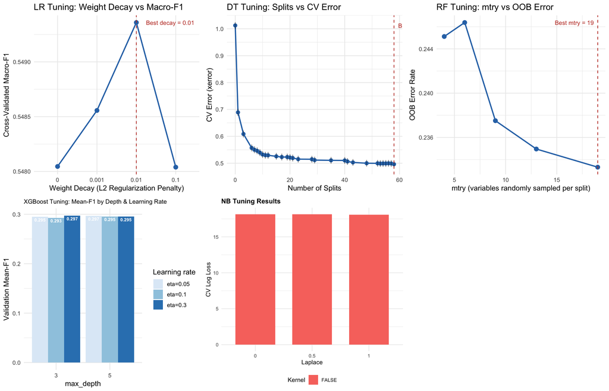

```r
plot_grid(p_lr_tune, p_dt_tune, p_rf_tune,
          p_xgb_tune_curve, p_nb_tune, NULL,
          ncol = 3, nrow = 2,
          labels = NULL,
          label_size = 11)
```

### 7 Model Evaluation & Selection

Table 7: Evaluation Metric Definitions

| Metric | Definition | Role |
| --- | --- | --- |
| Macro-F1 | Unweighted mean of per-class F1 scores | Primary metric - equal class weighting prevents majority classes masking poor Fatal performance |
| Fatal Recall | True positive rate for the Fatal class (Sensitivity) | Hard safety constraint (>= 0.50) - models missing too many Fatal crashes cannot be deployed |
| Weighted F1 | Class-prevalence-weighted mean of per-class F1 scores | Cross-check: penalises misclassification on common classes |
| Cohen’s Kappa | Agreement above chance: (Acc - ExpAcc) / (1 - ExpAcc) | Cross-check: robust to class imbalance; near-zero = near-random |

```r
# Build tuned metrics vectors
fr_tuned <- round(c(fatal_recall_lr_tuned, fatal_recall_dt_tuned,
                    as.numeric(fatal_recall_tuned), fatal_recall_xgb_tuned,
                    fatal_recall_knn, as.numeric(fatal_recall_nb_tuned)), 4)
mf1_tuned <- round(c(macro_f1_lr_tuned, macro_f1_dt_tuned,
                     as.numeric(macro_f1_tuned), macro_f1_xgb_tuned,
                     macro_f1_knn, macro_f1_nb_tuned), 4)
passes <- fr_tuned >= 0.50

# Rank passing models by Macro-F1; non-passing get "-"
rank_vec <- rep("-", 6)
passing_idx <- which(passes)
rank_order  <- passing_idx[order(mf1_tuned[passing_idx], decreasing = TRUE)]
rank_vec[rank_order] <- seq_along(rank_order)

decision_vec <- rep("Eliminated (Fatal Recall < 0.50)", 6)
decision_vec[passes & mf1_tuned < 0.50] <- "Pass constraint; low Macro-F1"
decision_vec[passes & mf1_tuned >= 0.50] <- "Dual-pass"
decision_vec[which.max(mf1_tuned * passes)] <- "Selected"

sel_tbl <- data.frame(
  Model         = c("Logistic Regression", "Decision Tree", "Random Forest",
                    "XGBoost", paste0("KNN (k=", k_knn, ")"), "Naive Bayes"),
  `Macro-F1`    = mf1_tuned,
  `Fatal Recall`= fr_tuned,
  `Weighted F1` = round(c(weighted_f1_lr_tuned, weighted_f1_dt_tuned,
                           as.numeric(weighted_f1_tuned), weighted_f1_xgb_tuned,
                           weighted_f1_knn, weighted_f1_nb_tuned), 4),
  Kappa         = round(c(kappa_lr_tuned, kappa_dt_tuned,
                           as.numeric(kappa_tuned), kappa_xgb_tuned,
                           kappa_knn, as.numeric(kappa_nb_tuned)), 4),
  Rank          = rank_vec,
  Decision      = decision_vec,
  check.names   = FALSE
)

selected_row <- which(sel_tbl$Decision == "Selected")

knitr::kable(sel_tbl, align = c("l", "r", "r", "r", "r", "c", "l"),
             caption = "Table 8: Model Selection - Tuned Performance and Decision") |>
  kableExtra::kable_styling(full_width = TRUE,
                            bootstrap_options = c("condensed"), font_size = 12) |>
  kableExtra::row_spec(0, bold = TRUE, background = "#2E74B5", color = "white") |>
  kableExtra::row_spec(selected_row, bold = TRUE, background = "#D5E8D4",
                       color = "#1a5c1a") |>
  kableExtra::column_spec(1, bold = TRUE) |>
  kableExtra::column_spec(3, color = "#d62728") |>
  kableExtra::column_spec(7, bold = TRUE)
```

Table 8: Model Selection - Tuned Performance and Decision

Model

Macro-F1

Fatal Recall

Weighted F1

Kappa

Rank

Decision

Logistic Regression

0.4400

0.7819

0.5902

0.2763

4

Pass constraint; low Macro-F1

Decision Tree

0.4433

0.7819

0.5944

0.2827

3

Pass constraint; low Macro-F1

Random Forest

0.6930

0.5053

0.7804

0.5441

1

Selected

XGBoost

0.2671

0.3298

0.4003

0.0026

Eliminated (Fatal Recall < 0.50)

KNN (k=18)

0.5334

0.6277

0.6702

0.3337

2

Dual-pass

Naive Bayes

0.2385

0.7500

0.2420

0.1082

5

Pass constraint; low Macro-F1

**Group 1 - Safety floor failure (Fatal Recall < 0.50):**

- **XGBoost** is eliminated: despite grid search over `nrounds`/`max_depth`/`eta`, the model converges to a near-trivial classifier. Kappa near 0 indicates near-random three-class discrimination. Root cause: one-hot expansion of high-cardinality categoricals interacts poorly with the inverse-frequency weighting scheme.

**Group 2 - High-recall but low-F1 (pass constraint, Macro-F1 < 0.50):**

- **Logistic Regression, Decision Tree, and Naive Bayes** all clear the Fatal Recall floor (>= 0.75) but remain below Macro-F1 = 0.50. They over-predict Fatal - high recall at the cost of precision on Injury and Non-casualty.
- **NB** is weakest in this group: its conditional independence assumption is violated by strong correlations between speed limit, urbanisation, lighting, and surface condition, capping both Macro-F1 and Weighted F1.

**Tuned confusion matrices:**

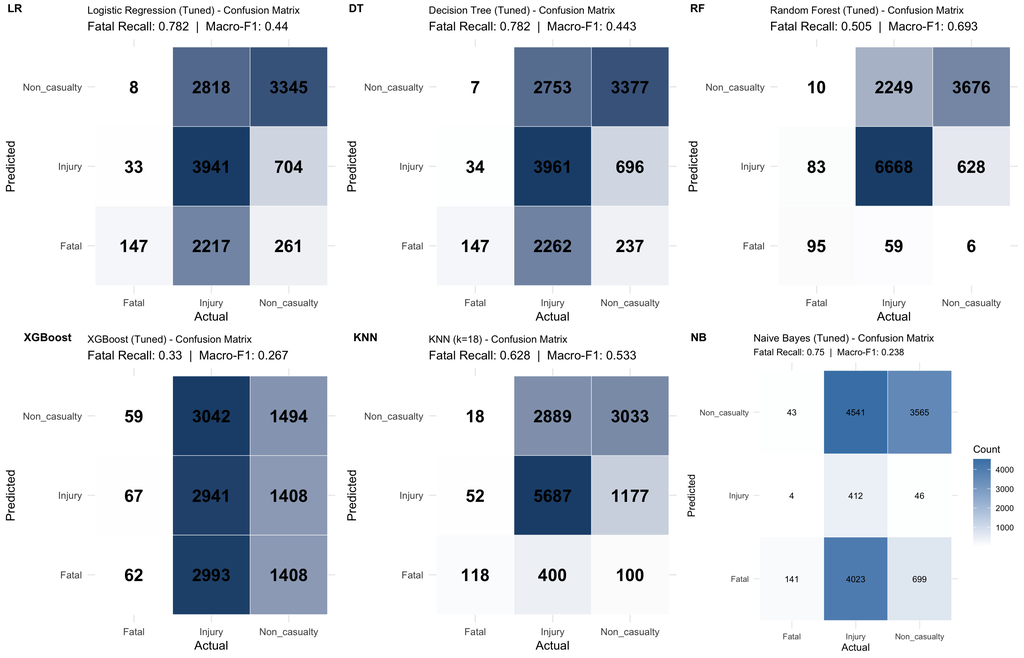

### 8 Final Results & Conclusion

```r
# 8.1 Prepare 2024 holdout data

year_col <- names(df_model)[grepl("year", names(df_model), ignore.case = TRUE)][1]

df_holdout_2024 <- df_model %>%
  filter(.data[[year_col]] == 2024) %>%
  filter(!is.na(`Degree of crash`))

# RF required variables
required_vars <- names(model_rf_tuned$forest$ncat)

x_2024 <- df_holdout_2024

# Add missing columns if needed
missing_vars <- setdiff(required_vars, names(x_2024))

for (v in missing_vars) {
  x_2024[[v]] <- NA
}

# Keep same variables and order
x_2024 <- x_2024[, required_vars, drop = FALSE]

# Pre-compute training set medians for numeric variables (use train, not holdout, to avoid leakage)
train_medians <- sapply(
  rf_x_train[, sapply(rf_x_train, is.numeric), drop = FALSE],
  median, na.rm = TRUE
)

# Handle missing values and factor levels
for (v in required_vars) {

  # If variable is categorical in RF
  if (v %in% names(model_rf_tuned$forest$xlevels)) {

    train_levels <- model_rf_tuned$forest$xlevels[[v]]

    # Convert to character first
    x_2024[[v]] <- as.character(x_2024[[v]])

    # Replace unseen or missing levels
    replacement_level <- if ("Unknown" %in% train_levels) {
      "Unknown"
    } else if ("Other" %in% train_levels) {
      "Other"
    } else {
      train_levels[1]
    }

    x_2024[[v]][is.na(x_2024[[v]]) | !(x_2024[[v]] %in% train_levels)] <- replacement_level

    x_2024[[v]] <- factor(x_2024[[v]], levels = train_levels)

  } else {

    # Numeric: impute with training median, not holdout median
    x_2024[[v]] <- as.numeric(x_2024[[v]])
    fill_val <- if (!is.null(train_medians[[v]]) && !is.na(train_medians[[v]])) {
      train_medians[[v]]
    } else {
      0
    }
    x_2024[[v]][is.na(x_2024[[v]])] <- fill_val
  }
}

# Outcome
y_2024 <- factor(
  df_holdout_2024$`Degree of crash`,
  levels = c("Fatal", "Injury", "Non_casualty")
)

# Check row count
nrow(x_2024)
table(y_2024)
# 8.2 Predict on 2024 holdout

pred_rf_2024 <- predict(

  model_rf_tuned,

  newdata = x_2024

)

cm_rf_2024 <- confusionMatrix(

  pred_rf_2024,

  y_2024

)

cm_rf_2024
# 8.3 Compute holdout metrics

recall_2024 <- cm_rf_2024$byClass[, "Sensitivity"]
precision_2024 <- cm_rf_2024$byClass[, "Pos Pred Value"]

f1_2024 <- 2 * precision_2024 * recall_2024 /
  (precision_2024 + recall_2024)

# Treat undefined F1 as 0
f1_2024[is.na(f1_2024)] <- 0

macro_f1_2024 <- mean(f1_2024)

fatal_recall_2024 <- recall_2024["Class: Fatal"]

class_weights_2024 <- prop.table(table(y_2024))
f1_names_2024 <- gsub("Class: ", "", names(f1_2024))

weighted_f1_2024 <- sum(
  f1_2024 * class_weights_2024[f1_names_2024],
  na.rm = TRUE
)

kappa_2024 <- cm_rf_2024$overall["Kappa"]

rf_2024_metrics <- data.frame(
  Model = "Tuned RF - 2024 Holdout",
  Macro_F1 = round(macro_f1_2024, 3),
  Fatal_Recall = round(as.numeric(fatal_recall_2024), 3),
  Weighted_F1 = round(weighted_f1_2024, 3),
  Kappa = round(as.numeric(kappa_2024), 3),
  row.names = NULL
)

knitr::kable(
  rf_2024_metrics,
  caption = "Tuned Random Forest Performance on 2024 Holdout Data"
)
# 8.4 Holdout confusion matrix

cm_rf_2024_df <- as.data.frame(cm_rf_2024$table)

p_rf_2024_cm <- ggplot(
  cm_rf_2024_df,
  aes(x = Reference, y = Prediction, fill = Freq)
) +
  geom_tile(color = "white") +
  geom_text(aes(label = Freq), size = 3.5) +
  scale_fill_gradient(low = "white", high = "steelblue") +
  labs(
    title = "RF (Tuned) - 2024 Holdout Confusion Matrix",
    subtitle = paste0("Fatal Recall: ", round(fatal_recall_2024, 3),
                      "  |  Macro-F1: ", round(macro_f1_2024, 3)),
    x = "Actual", y = "Predicted",
    fill = "Count"
  ) +
  theme_minimal() +
  theme(plot.title = element_text(size = 10))

p_rf_2024_cm
```

[output not shown]

```r
ggsave(
  "plots/8_rf_2024_holdout_confusion_matrix.png",
  p_rf_2024_cm,
  width = 6,
  height = 4,
  dpi = 220
)
```

```r
knitr::kable(
  rf_2024_metrics,
  col.names = c("Model", "Macro-F1", "Fatal Recall", "Weighted F1", "Kappa"),
  caption = "Table 9: Tuned Random Forest - 2024 Temporal Holdout Performance"
) |>
  kableExtra::kable_styling(full_width = FALSE,
                            bootstrap_options = c("striped", "condensed"),
                            font_size = 12) |>
  kableExtra::row_spec(0, bold = TRUE, background = "#2E74B5", color = "white") |>
  kableExtra::column_spec(1, bold = TRUE)
```

Table 9: Tuned Random Forest - 2024 Temporal Holdout Performance

| Model | Macro-F1 | Fatal Recall | Weighted F1 | Kappa |
| --- | --- | --- | --- | --- |
| Tuned RF - 2024 Holdout | 0.359 | 0.188 | 0.586 | 0.055 |

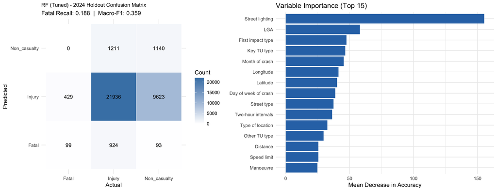

```r
imp_df_final <- as.data.frame(importance(model_rf_tuned, type = 1))
imp_df_final$Feature <- rownames(imp_df_final)
p_varimp_final <- imp_df_final %>%
  arrange(desc(MeanDecreaseAccuracy)) %>%
  head(15) %>%
  ggplot(aes(x = reorder(Feature, MeanDecreaseAccuracy), y = MeanDecreaseAccuracy)) +
  geom_col(fill = "#2E74B5") +
  coord_flip() +
  labs(title = "Variable Importance (Top 15)",
       x = NULL, y = "Mean Decrease in Accuracy") +
  theme_minimal(base_size = 11)

plot_grid(p_rf_2024_cm, p_varimp_final, ncol = 2, rel_widths = c(1, 1.2))
```

**Holdout performance (2024 unseen data):**

- Fatal Recall collapsed from 0.505 (test set) to 0.188 - only 18.8% of actual Fatal crashes correctly identified, with the rest misclassified as Injury
- Macro-F1 fell from 0.693 to 0.359, with Kappa dropping to 0.055 (near-chance agreement)
- Weighted F1 (0.586) is deceptively high - the model predicts Injury for almost everything, and Injury dominates the 2024 holdout

**Why generalisation failed:**

- **Temporal distribution shift** - training used a balanced set (1:10:10 ratio) but 2024 holdout reflects the natural ~1:47:23 distribution, and decision boundaries trained on the balanced set do not transfer
- **Top predictors are time-sensitive** - Street lighting, LGA, and Key TU type shift with infrastructure upgrades and reporting practice changes year-on-year
- **No recalibration** - predicted probabilities were not threshold-calibrated for the Fatal class, with the default 0.33 threshold being too high given 1.4% natural prevalence

**Variable importance findings:**

- Street lighting and LGA dominate importance, suggesting crash severity in NSW is strongly tied to infrastructure quality and geographic context
- Temporal features (Month, Day of week, Two-hour intervals) appear in the top 15, confirming time-of-day and seasonal patterns carry predictive signal
- Speed limit ranks lower than expected - likely because most crashes cluster in 50-60 km/h zones, reducing its discriminative power

**Limitations:**

- Undersampling discards ~80% of majority-class rows, reducing the information available for learning Injury/Non-casualty boundaries
- Euclidean distance on OHE features (used by KNN) is a known limitation for high-cardinality categorical data
- Model was trained on a static 2020-2023 window with no temporal trend features

**Future work:**

- Rolling-window retraining (e.g., retrain annually on most recent 3 years) to track distribution drift
- Probability threshold calibration for the Fatal class to recover recall under natural class prevalence
- Explore crash-level aggregation strategies and time-series features to explicitly model year-on-year trends

**Answer to the research question:**

Given environmental conditions and traffic unit characteristics, can we predict NSW road crash severity as a three-class problem (Fatal / Injury / Non-casualty)? **Partially yes.** The tuned Random Forest achieves strong discrimination on the 2020-2023 test set (Macro-F1 = 0.693, Fatal Recall = 0.505), demonstrating that the chosen predictor set carries genuine signal for separating severity classes. However, the sharp generalisation drop on the 2024 holdout (Fatal Recall = 0.188) shows that prediction is sensitive to temporal distribution shift and cannot yet be considered reliable for deployment without periodic retraining and threshold recalibration.

#### References

Chawla, N.V., Bowyer, K.W., Hall, L.O., & Kegelmeyer, W.P. (2002). SMOTE: Synthetic Minority Over-sampling Technique. *Journal of Artificial Intelligence Research*, 16, 321–357. [https://doi.org/10.1613/jair.953](https://www.jair.org/index.php/jair/article/view/10302)

Cover, T.M. & Hart, P.E. (1967). Nearest neighbor pattern classification. *IEEE Transactions on Information Theory*, 13(1), 21–27. [https://doi.org/10.1109/TIT.1967.1053964](https://ieeexplore.ieee.org/document/1053964)

Hastie, T., Tibshirani, R., & Friedman, J. (2009). *The Elements of Statistical Learning* (2nd ed.). Springer. https://hastie.su.domains/ElemStatLearn/

James, G., Witten, D., Hastie, T., & Tibshirani, R. (2021). *An Introduction to Statistical Learning* (2nd ed.). Springer. https://www.statlearning.com

Transport for NSW. (2024). NSW road crash data 2020–2024 [Dataset]. Australian Government Open Data Platform. https://www.data.gov.au/data/dataset/nsw-2-nsw-crash-data

#### Acknowledgement of AI

Group 07 (Workshop 12) declares that we used ChatGPT (GPT-5.3, OpenAI, https://chatgpt.com) and Claude Sonnet 4.5 (Anthropic, https://claude.ai) for code refinement, grammar checking, making informed coding decisions, and reviewing report content against the marking rubric. The authors retain full understanding of all decisions made with AI assistance.